# LBB7

Yvonne Lam

10/10/2019

# Report

Models will be built using logistic regression and knn algorithm to do classification predictions. The dataset used is *wholesale.csv*, and it contains annual spending on diverse product categories by clients of a wholesale distributor. The clients are categorised into 2 big groups, Horeca (Hotel, Restaurants and Cafes) and Retail.

**Objective**:  
To predict and correctly classify Horeca in the target variable (Industry)

## Analysis

### Data Preparation

```r
#read data
wholesale <- read.csv("data_input/wholesale.csv")
str(wholesale)
```

```
## 'data.frame':    440 obs. of  8 variables:
##  $ Channel         : int  2 2 2 1 2 2 2 2 1 2 ...
##  $ Region          : int  3 3 3 3 3 3 3 3 3 3 ...
##  $ Fresh           : int  12669 7057 6353 13265 22615 9413 12126 7579 5963 6006 ...
##  $ Milk            : int  9656 9810 8808 1196 5410 8259 3199 4956 3648 11093 ...
##  $ Grocery         : int  7561 9568 7684 4221 7198 5126 6975 9426 6192 18881 ...
##  $ Frozen          : int  214 1762 2405 6404 3915 666 480 1669 425 1159 ...
##  $ Detergents_Paper: int  2674 3293 3516 507 1777 1795 3140 3321 1716 7425 ...
##  $ Delicassen      : int  1338 1776 7844 1788 5185 1451 545 2566 750 2098 ...
```

```r
#check for missing values
summary(wholesale)
```

```
##     Channel          Region          Fresh             Milk
##  Min.   :1.000   Min.   :1.000   Min.   :     3   Min.   :   55
##  1st Qu.:1.000   1st Qu.:2.000   1st Qu.:  3128   1st Qu.: 1533
##  Median :1.000   Median :3.000   Median :  8504   Median : 3627
##  Mean   :1.323   Mean   :2.543   Mean   : 12000   Mean   : 5796
##  3rd Qu.:2.000   3rd Qu.:3.000   3rd Qu.: 16934   3rd Qu.: 7190
##  Max.   :2.000   Max.   :3.000   Max.   :112151   Max.   :73498
##     Grocery          Frozen        Detergents_Paper    Delicassen
##  Min.   :    3   Min.   :   25.0   Min.   :    3.0   Min.   :    3.0
##  1st Qu.: 2153   1st Qu.:  742.2   1st Qu.:  256.8   1st Qu.:  408.2
##  Median : 4756   Median : 1526.0   Median :  816.5   Median :  965.5
##  Mean   : 7951   Mean   : 3071.9   Mean   : 2881.5   Mean   : 1524.9
##  3rd Qu.:10656   3rd Qu.: 3554.2   3rd Qu.: 3922.0   3rd Qu.: 1820.2
##  Max.   :92780   Max.   :60869.0   Max.   :40827.0   Max.   :47943.0
```

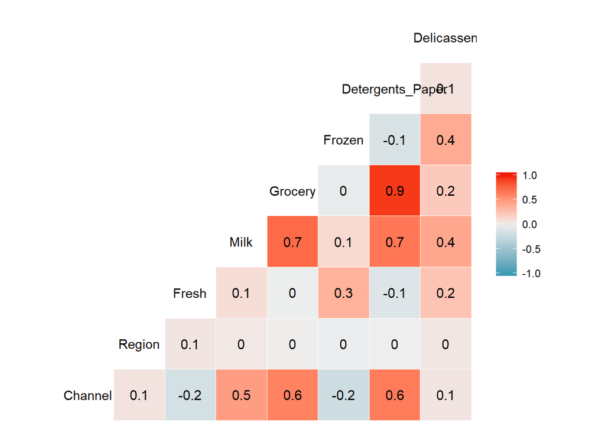

```r
#peek at correlations of variables
ggcorr(wholesale, label = T)
```

```r
#drop Region variable because not useful
wholesale <- wholesale[,-2]

#change Channel into a binary factor Industry
wholesale <- wholesale %>%
  mutate(Industry = if_else(Channel >1, 1, 0))

wholesale$Industry <- as.factor(wholesale$Industry)
```

Looking at the variable correlations, `Milk`, `Grocery` and `Detergents_Paper` are positively correlated with response variable `Industry`.  
`Grocery` and `Detergents_Paper` is highly correlated with each other. `Milk` is also correlated with both `Grocery` and `Detergents_Paper`. Multicollinearity occurred, so 1 or 2 variables should be dropped from subsequent models.

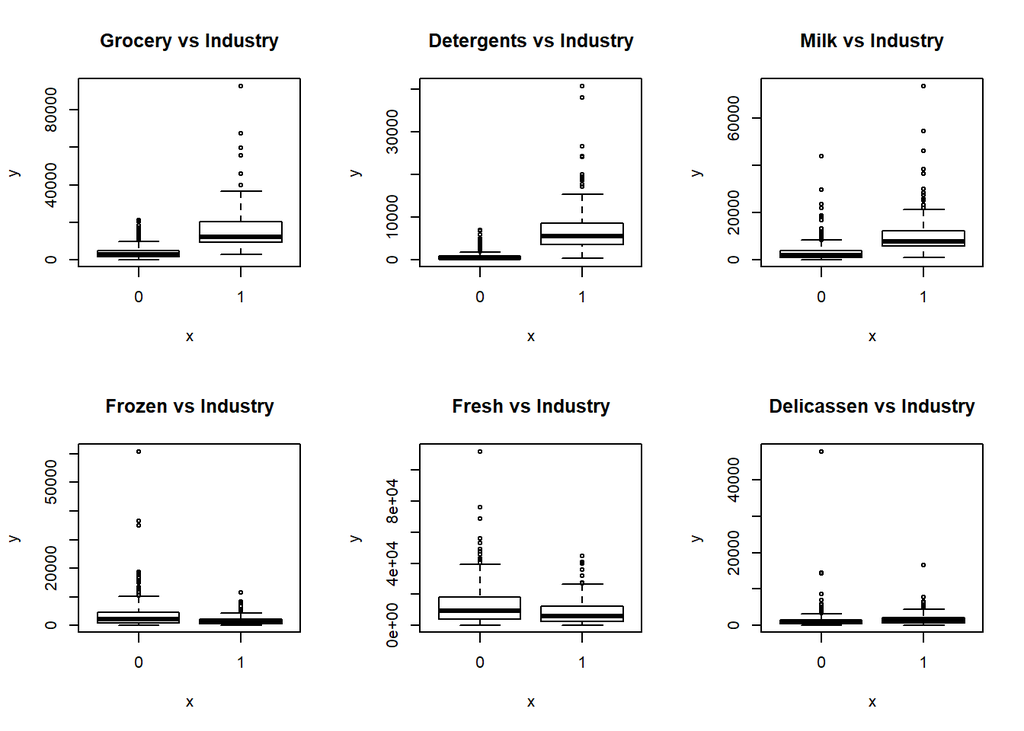

```r
#Understand data
par(mfrow = c(2,3))
plot(wholesale$Industry,wholesale$Grocery, main="Grocery vs Industry")
plot(wholesale$Industry,wholesale$Detergents_Paper, main="Detergents vs Industry")
plot(wholesale$Industry,wholesale$Milk, main="Milk vs Industry")
plot(wholesale$Industry,wholesale$Frozen, main="Frozen vs Industry")
plot(wholesale$Industry,wholesale$Fresh, main="Fresh vs Industry")
plot(wholesale$Industry,wholesale$Delicassen, main = "Delicassen vs Industry")
```

```r
#check proportion of Industry (target variable)
prop.table(table(wholesale$Industry))*100
```

```
##
##        0        1
## 67.72727 32.27273
```

Data is not imbalanced, no need for upsampling.

```r
accuracy_base <- round(298/(298+142),3)
accuracy_base
```

```
## [1] 0.677
```

Baseline accuracy is 67.7% (prediction models need to have accuracy higher than this).

### Model (Logistic Regression)

```r
#split train and test sets
set.seed(300)
sample_num <- sample(nrow(wholesale), nrow(wholesale)*0.8)
wholesale_train <- wholesale[sample_num,2:8]
wholesale_test <- wholesale[-sample_num,2:8]

#Check proportion of train set
prop.table(table(wholesale_train$Industry))
```

```
##
##         0         1
## 0.6505682 0.3494318
```

```r
#Build models
logit_base <- glm(Industry ~., data = wholesale_train, family = "binomial")
summary(logit_base)
```

```
##
## Call:
## glm(formula = Industry ~ ., family = "binomial", data = wholesale_train)
##
## Deviance Residuals:
##     Min       1Q   Median       3Q      Max
## -3.1939  -0.2988  -0.2085   0.0486   3.0270
##
## Coefficients:
##                    Estimate Std. Error z value Pr(>|z|)
## (Intercept)      -3.928e+00  5.050e-01  -7.778 7.39e-15 ***
## Fresh            -6.732e-06  1.821e-05  -0.370  0.71169
## Milk              1.234e-05  6.827e-05   0.181  0.85660
## Grocery           1.986e-04  7.393e-05   2.686  0.00723 **
## Frozen           -1.305e-04  9.693e-05  -1.346  0.17824
## Detergents_Paper  9.267e-04  1.580e-04   5.866 4.46e-09 ***
## Delicassen        3.281e-05  9.716e-05   0.338  0.73563
## ---
## Signif. codes:  0 '***' 0.001 '**' 0.01 '*' 0.05 '.' 0.1 ' ' 1
##
## (Dispersion parameter for binomial family taken to be 1)
##
##     Null deviance: 455.55  on 351  degrees of freedom
## Residual deviance: 151.54  on 345  degrees of freedom
## AIC: 165.54
##
## Number of Fisher Scoring iterations: 7
```

```r
#stepwise regression to choose best model using lowest AIC score
logit_step <- step(logit_base, trace = T)
```

```
## Start:  AIC=165.54
## Industry ~ Fresh + Milk + Grocery + Frozen + Detergents_Paper +
##     Delicassen
```

```
##                    Df Deviance    AIC
## - Milk              1   151.57 163.57
## - Delicassen        1   151.65 163.65
## - Fresh             1   151.68 163.68
## <none>                  151.54 165.54
## - Frozen            1   154.48 166.48
## - Grocery           1   159.58 171.58
## - Detergents_Paper  1   191.24 203.24
```

```
##
## Step:  AIC=163.57
## Industry ~ Fresh + Grocery + Frozen + Detergents_Paper + Delicassen
```

```
##                    Df Deviance    AIC
## - Fresh             1   151.72 161.72
## - Delicassen        1   151.73 161.73
## <none>                  151.57 163.57
## - Frozen            1   154.55 164.55
## - Grocery           1   164.23 174.23
## - Detergents_Paper  1   191.36 201.36
```

```
##
## Step:  AIC=161.72
## Industry ~ Grocery + Frozen + Detergents_Paper + Delicassen
```

```
##                    Df Deviance    AIC
## - Delicassen        1   151.86 159.86
## <none>                  151.72 161.72
## - Frozen            1   155.33 163.33
## - Grocery           1   164.23 172.23
## - Detergents_Paper  1   193.80 201.80
```

```
##
## Step:  AIC=159.86
## Industry ~ Grocery + Frozen + Detergents_Paper
```

```
##                    Df Deviance    AIC
## <none>                  151.86 159.86
## - Frozen            1   156.07 162.07
## - Grocery           1   165.69 171.69
## - Detergents_Paper  1   193.80 199.80
```

```r
logit_2 <- glm(formula = Industry ~ Grocery + Frozen + Detergents_Paper,
    family = "binomial", data = wholesale_train)
summary(logit_2)
```

```
##
## Call:
## glm(formula = Industry ~ Grocery + Frozen + Detergents_Paper,
##     family = "binomial", data = wholesale_train)
##
## Deviance Residuals:
##     Min       1Q   Median       3Q      Max
## -3.2032  -0.3010  -0.2101   0.0456   3.0008
##
## Coefficients:
##                    Estimate Std. Error z value Pr(>|z|)
## (Intercept)      -3.998e+00  4.993e-01  -8.006 1.18e-15 ***
## Grocery           2.076e-04  5.959e-05   3.484 0.000494 ***
## Frozen           -1.188e-04  7.969e-05  -1.491 0.135882
## Detergents_Paper  9.356e-04  1.566e-04   5.973 2.33e-09 ***
## ---
## Signif. codes:  0 '***' 0.001 '**' 0.01 '*' 0.05 '.' 0.1 ' ' 1
##
## (Dispersion parameter for binomial family taken to be 1)
##
##     Null deviance: 455.55  on 351  degrees of freedom
## Residual deviance: 151.86  on 348  degrees of freedom
## AIC: 159.86
##
## Number of Fisher Scoring iterations: 7
```

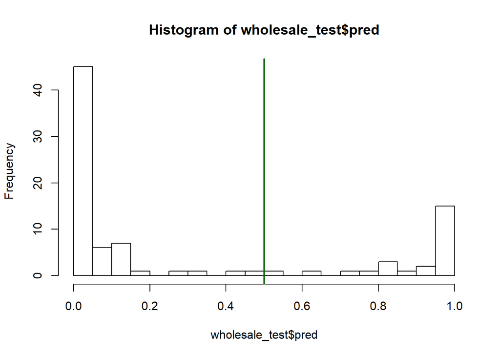

```r
#predict probabilities
wholesale_test$pred <- predict(logit_2, wholesale_test, type = "response")

hist(wholesale_test$pred, breaks = 20)
abline(v = 0.5, col = "darkgreen", lwd=2)
```

```r
#confusion matrix
table("predicted" = as.numeric(wholesale_test$pred >= 0.5), "actual" = as.numeric(wholesale_test$Industry))
```

```
##          actual
## predicted  1  2
##         0 61  2
##         1  8 17
```

```r
accuracy_log <- round((61+17)/(61+17+2+8),3)
#model accuracy is 88.6%, higher than baseline of 67.7%

#sensitivity
sens_log <- round(61/(61+8),3)
sens_log
```

```
## [1] 0.884
```

```r
#Precision
prec_log <- round(61/(61+2),3)
prec_log
```

```
## [1] 0.968
```

```r
#increasing threshold number
table("predicted" = as.numeric(wholesale_test$pred >= 0.6), "actual" = as.numeric(wholesale_test$Industry))
```

```
##          actual
## predicted  1  2
##         0 61  3
##         1  8 16
```

```r
#accuracy
a2 <- round((61+16)/(61+16+8+3),3)

#sensitivity
sens2 <- round(61/(61+8),3)

#precision
prec2 <- round(61/(61+3),3)

data.frame(row.names = c("Accuracy", "Sensitivity", "Precision"),
           "Threshold 0.5" = c(accuracy_log,sens_log,prec_log),
           "Threshold 0.6" = c(a2,sens2,prec2))
```

```
##             Threshold.0.5 Threshold.0.6
## Accuracy            0.886         0.875
## Sensitivity         0.884         0.884
## Precision           0.968         0.953
```

By increasing the threshold from 0.5 to 0.6, sensitivity remains the same, which means no change in number of Horeca being correctly predicted. However, precision is slightly lowered, which means more Horeca is classified wrongly. Hence, this is not a good model and we should not change threshold number.

### Model (k-Nearest Neighbour)

```r
#Data prep
head(wholesale)
```

```
##   Channel Fresh Milk Grocery Frozen Detergents_Paper Delicassen Industry
## 1       2 12669 9656    7561    214             2674       1338        1
## 2       2  7057 9810    9568   1762             3293       1776        1
## 3       2  6353 8808    7684   2405             3516       7844        1
## 4       1 13265 1196    4221   6404              507       1788        0
## 5       2 22615 5410    7198   3915             1777       5185        1
## 6       2  9413 8259    5126    666             1795       1451        1
```

```r
#Make Channel variable a factor
wholesale$Industry <- factor(wholesale$Channel, levels=c(1,2), labels=c("Horeca", "Retail"))

#create normalize function
normalize <- function(x){
  return(
    (x-min(x))/(max(x)-min(x))
  )
}
#normalize df of predictors only
wholesale_n <- as.data.frame(lapply(wholesale[,2:7], normalize))
```

```r
#split train and test sets
set.seed(240)
split <- sample(nrow(wholesale), nrow(wholesale)*0.8)
wholesale_knn_train <- wholesale_n[split,]
wholesale_knn_test <- wholesale_n[-split,]

wholesale_knn_train_label <- wholesale[split,8]
wholesale_knn_test_label <- wholesale[-split,8]

#check proportion of train label
prop.table(table(wholesale_knn_train_label))
```

```
## wholesale_knn_train_label
##  Horeca  Retail
## 0.65625 0.34375
```

```r
#run knn
wholesale_pred <- knn(train = wholesale_knn_train, test = wholesale_knn_test, cl = wholesale_knn_train_label, k = 21)
#k=21 is used as it is the sqrt of entire dataset, n=440

#confusion matrix
table("predicted" = as.numeric(wholesale_pred), "actual" = wholesale_knn_test_label)
```

```
##          actual
## predicted Horeca Retail
##         1     64      2
##         2      3     19
```

```r
accuracy_knn <- round((64+19)/(64+19+3+2),3)
accuracy_knn
```

```
## [1] 0.943
```

```r
sens_knn <- round(64/(64+3),3)

prec_knn <- round(64/(64+2),3)
```

```r
#change k value for knn
wholesale_pred2 <- knn(train = wholesale_knn_train, test = wholesale_knn_test, cl = wholesale_knn_train_label, k = 20)

#confusion matrix
table("predicted" = as.numeric(wholesale_pred2), "actual" = wholesale_knn_test_label)
```

```
##          actual
## predicted Horeca Retail
##         1     64      2
##         2      3     19
```

```r
accuracy_knn2 <- round((63+19)/(63+19+4+2),3)

sens_knn2 <- round(63/(63+4),3)

prec_knn2 <- round(63/(63+2),3)

data.frame(row.names = c("Accuracy", "Sensitivity", "Precision"),
           "k=21"= c(accuracy_knn,sens_knn,prec_knn),
           "k=20" = c(accuracy_knn2,sens_knn2,prec_knn2))
```

[output not shown]

### Compare Models

```r
#Based on Accuracy
Model <- c("Base","Logistic","kNN")
Accuracy <- c(accuracy_base, accuracy_log, accuracy_knn)
data.frame(Model, Accuracy)
```

```
##      Model Accuracy
## 1     Base    0.677
## 2 Logistic    0.886
## 3      kNN    0.943
```

Based on confusion matrix, knn algorithm produces better prediction results in general compared to logistic regression since the accuracy of predictions is much higher.

```r
#Based on Sensitivity and Precision
model2 <- c("Logistic","kNN")
sens <- c(sens_log,sens_knn)
prec <- c(prec_log,prec_knn)
data.frame("Model" = model2, "Sensitivity" = sens, "Precision" = prec)
```

```
##      Model Sensitivity Precision
## 1 Logistic       0.884     0.968
## 2      kNN       0.955     0.970
```

Since the end goal is to predict and correctly classify ‘Horeca’, we want the sensitivity score of the models to be as high as possible. Also, the precision score should be high as well to avoid wrongly classifying Horeca instances as Retail. Therefore, kNN is the better model due to both Sensitivity and Precision being higher compared to the logistic regression model.

## LBB Task

Using R Markdown, demonstrate the use of BOTH logistic regression AND knn algorithm. Choose only one of the following data sets: lbb_loans.csv dataset for predicting credit risk (similar to example used in class) wholesale.csv dataset (please see Optional section “Building knn from scratch” for explanation) Any suitable data set of your choice that you want to do classification predictions Explain your findings where necessary and show the necessary data preparation steps.

To help you through the exercise, consider the following questions throughout the document: If you use a logistic regression, how do we correctly interpret the coefficients obtained from your logistic regression? How do we know which of the variables are more statistically significant as predictors in your logistic regression model? What is your accuracy? Was the logistic regression better than kNN in terms of accuracy? Was the logistic regression better than our kNN model at explaining which of the variables are good predictors? What are some strategies to improve your model? List down 1 disadvantage and 1 strength of each of the approach (kNN and logistic regression)

Participants should be awarded the full points if: The preprocessing steps are done and showed an understanding of using train / test sets Analysis on how to improve both of their model are documented. The model performance is sufficiently explained (accuracy may not be the most helpful metric).

## Full Code

```r
library(dplyr)
library(caret)
library(class)
library(GGally)

#DATA PREP
#read data
wholesale <- read.csv("data_input/wholesale.csv")
str(wholesale)

#check for missing values
summary(wholesale)

#peek at correlations of variables
ggcorr(wholesale, label = T)

#drop Region variable because not useful
wholesale <- wholesale[,-2]

#change Channel into a binary factor Industry
wholesale <- wholesale %>%
  mutate(Industry = if_else(Channel >1, 1, 0))

wholesale$Industry <- as.factor(wholesale$Industry)

#Understand data
par(mfrow = c(2,3))
plot(wholesale$Industry,wholesale$Grocery, main="Grocery vs Industry")
plot(wholesale$Industry,wholesale$Detergents_Paper, main="Detergents vs Industry")
plot(wholesale$Industry,wholesale$Milk, main="Milk vs Industry")
plot(wholesale$Industry,wholesale$Frozen, main="Frozen vs Industry")
plot(wholesale$Industry,wholesale$Fresh, main="Fresh vs Industry")
plot(wholesale$Industry,wholesale$Delicassen, main = "Delicassen vs Industry")

#check proportion of Industry (target variable)
prop.table(table(wholesale$Industry))*100

accuracy_base <- round(298/(298+142),3)
accuracy_base

#LOGISTIC REGRESSION
#split train and test sets
set.seed(300)
sample_num <- sample(nrow(wholesale), nrow(wholesale)*0.8)
wholesale_train <- wholesale[sample_num,2:8]
wholesale_test <- wholesale[-sample_num,2:8]

#Check proportion of train set
prop.table(table(wholesale_train$Industry))

#Build models
logit_base <- glm(Industry ~., data = wholesale_train, family = "binomial")
summary(logit_base)

#stepwise regression to choose best model using lowest AIC score
logit_step <- step(logit_base, trace = T)
logit_2 <- glm(formula = Industry ~ Grocery + Frozen + Detergents_Paper,
    family = "binomial", data = wholesale_train)
summary(logit_2)

#predict probabilities
wholesale_test$pred <- predict(logit_2, wholesale_test, type = "response")

hist(wholesale_test$pred, breaks = 20)
abline(v = 0.5, col = "darkgreen", lwd=2)

#confusion matrix
table("predicted" = as.numeric(wholesale_test$pred >= 0.5), "actual" = as.numeric(wholesale_test$Industry))

accuracy_log <- round((61+17)/(61+17+2+8),3)
#model accuracy is 88.6%, higher than baseline of 67.7%

#sensitivity
sens_log <- round(61/(61+8),3)
sens_log

#Precision
prec_log <- round(61/(61+2),3)
prec_log

#increasing threshold number
table("predicted" = as.numeric(wholesale_test$pred >= 0.6), "actual" = as.numeric(wholesale_test$Industry))

#accuracy
a2 <- round((61+16)/(61+16+8+3),3)

#sensitivity
sens2 <- round(61/(61+8),3)

#precision
prec2 <- round(61/(61+3),3)

data.frame(row.names = c("Accuracy", "Sensitivity", "Precision"),
           "Threshold 0.5" = c(accuracy_log,sens_log,prec_log),
           "Threshold 0.6" = c(a2,sens2,prec2))

#KNN
#Data prep for kNN
head(wholesale)

#Make Channel variable a factor
wholesale$Industry <- factor(wholesale$Channel, levels=c(1,2), labels=c("Horeca", "Retail"))

#create normalize function
normalize <- function(x){
  return(
    (x-min(x))/(max(x)-min(x))
  )
}
#normalize df of predictors only
wholesale_n <- as.data.frame(lapply(wholesale[,2:7], normalize))

#split train and test sets
set.seed(240)
split <- sample(nrow(wholesale), nrow(wholesale)*0.8)
wholesale_knn_train <- wholesale_n[split,]
wholesale_knn_test <- wholesale_n[-split,]

wholesale_knn_train_label <- wholesale[split,8]
wholesale_knn_test_label <- wholesale[-split,8]

#check proportion of train label
prop.table(table(wholesale_knn_train_label))

#run knn
wholesale_pred <- knn(train = wholesale_knn_train, test = wholesale_knn_test, cl = wholesale_knn_train_label, k = 21)

#confusion matrix
table("predicted" = as.numeric(wholesale_pred), "actual" = wholesale_knn_test_label)

accuracy_knn <- round((64+19)/(64+19+3+2),3)
accuracy_knn

sens_knn <- round(64/(64+3),3)

prec_knn <- round(64/(64+2),3)

#change k value for knn
wholesale_pred2 <- knn(train = wholesale_knn_train, test = wholesale_knn_test, cl = wholesale_knn_train_label, k = 20)

#confusion matrix
table("predicted" = as.numeric(wholesale_pred2), "actual" = wholesale_knn_test_label)

accuracy_knn2 <- round((63+19)/(63+19+4+2),3)

sens_knn2 <- round(63/(63+4),3)

prec_knn2 <- round(63/(63+2),3)

data.frame(row.names = c("Accuracy", "Sensitivity", "Precision"),
           "k=21"= c(accuracy_knn,sens_knn,prec_knn),
           "k=20" = c(accuracy_knn2,sens_knn2,prec_knn2))

#COMPARE MODELS
#Based on Accuracy
Model <- c("Base","Logistic","kNN")
Accuracy <- c(accuracy_base, accuracy_log, accuracy_knn)
data.frame(Model, Accuracy)

#Based on Sensitivity and Precision
model2 <- c("Logistic","kNN")
sens <- c(sens_log,sens_knn)
prec <- c(prec_log,prec_knn)
data.frame("Model" = model2, "Sensitivity" = sens, "Precision" = prec)
```

# Findings and Summary

kNN produced the better prediction model as explained in the previous section. However, it is an algorithm which does not learn much from the data. kNN uses distance from the instance to k number of neighbours to classify each new case. On the other hand, the logistic model was better at explaining which variables were good predictors of the end result. It uses predictors to create a regression curve, hence the more statistically significant a predictor, the more accurate the prediction outcome is.

**Logistic Regression**  
Advantage: predicts probability of an outcome, useful when required for ranking instances  
Disadvantage: vulnerable to overfitting when there are too many variables

**K-Nearest Neighbour**  
Advantage: simple to implement and model is instance-based  
Disadvantage: memory-intensive, and perform poorly for data with many variables

Other than using different algorithms, there were attempts to tune algorithm parameters to improve our model. For instance, changing the k value in the kNN algorithm and the threshold probability in the logistic regression model. Also, instead of solely using accuracy scores from the confusion matrix to evaluate model performance, sensitivity and precision scores were used as well. More weightage was given to sensitivity and precision scores as they were more useful in achieving our objective of predicting and correctly classifying Horeca compared to accuracy scores.